# Análisis Estadístico Multivariante Control 1 de Prácticas

Francisco Javier Mercader Martínez

27/02/2024

```r
library("readxl")
datos <- read_xlsx("data/zumos_B.xlsx")
```

# Problema 1

1. Realiza un diagrama de caja y biggotes del problema e indica si hay atípicos (no elimines ninguno). Realiza los diagramas de dispersión por pares de variables y comenta los resultados más relevantes.

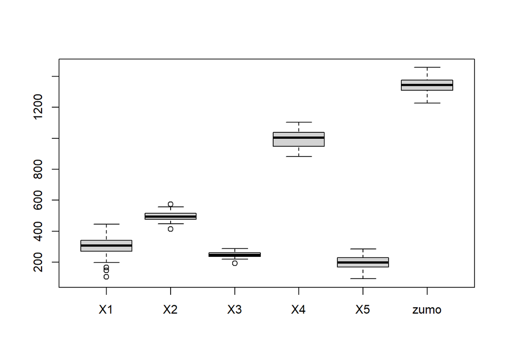

```r
boxplot(datos)
```

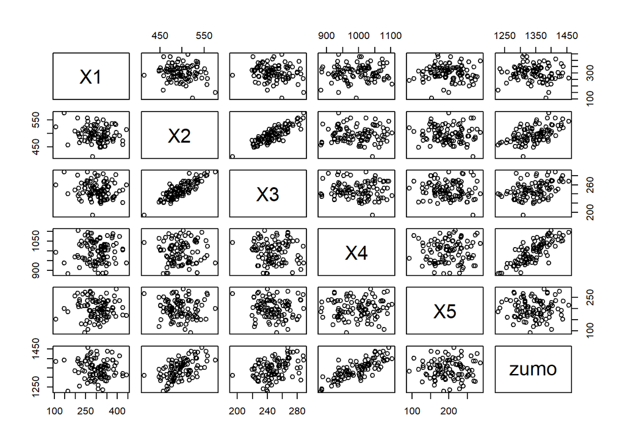

```r
plot(datos)
```

2)¿Podemos suponer que nuestra variable respuesta es Normal? Realiza un test hipótesis y comenta el resutlado.

Por el planteamiento del problema he deducido que la variable respuesta es `zumo`.

```r
shapiro.test(datos$zumo)
```

```
##
##  Shapiro-Wilk normality test
##
## data:  datos$zumo
## W = 0.9926, p-value = 0.8625
```

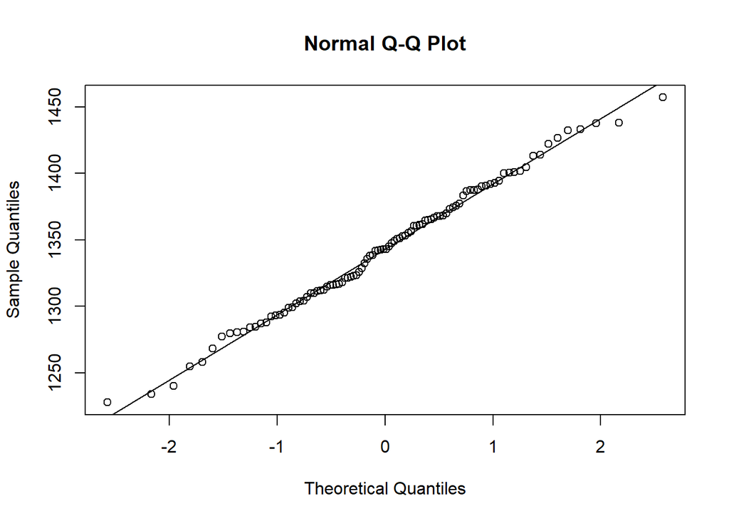

```r
qqnorm(datos$zumo)
qqline(datos$zumo)
```

Realizando la prueba de Shapiro se puede ver que `p-value`tiene un valor bastante alto por lo que deduimos que se trata de una variable normalizada.

3. Realiza la familia de transformaciones de Box-Cox, variando el expoenente lambda en (-5,5) para confirmar que sería adecuado no tansformar la variable respuesta

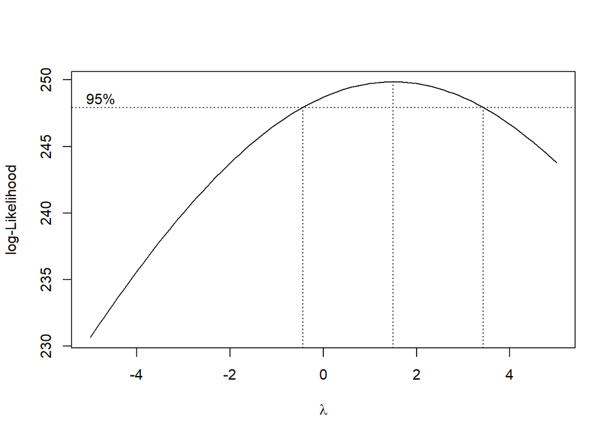

```r
library("MASS")
boxcox(lm(zumo ~ ., data = datos), lambda = seq(-5,5,1/10))
```

4) Calcula la matriz de corrrelaciones de todas las varaibles del problema. ¿Qué regresores del modelo presentan una más estrecha relación lineal entre sí? ¿Cuál es la primera variable del modelo?

```r
cor(datos)
```

```
##               X1          X2          X3          X4            X5
## X1    1.00000000 -0.14779512 -0.14265044  0.05092766 -0.0165631257
## X2   -0.14779512  1.00000000  0.85309117  0.02253789 -0.0613300972
## X3   -0.14265044  0.85309117  1.00000000 -0.06050727 -0.0981823543
## X4    0.05092766  0.02253789 -0.06050727  1.00000000  0.0491572214
## X5   -0.01656313 -0.06133010 -0.09818235  0.04915722  1.0000000000
## zumo -0.05822681  0.55564691  0.40764166  0.81189174  0.0006693336
##               zumo
## X1   -0.0582268136
## X2    0.5556469056
## X3    0.4076416577
## X4    0.8118917408
## X5    0.0006693336
## zumo  1.0000000000
```

```r
# Las varaibles con más relación son X2 y X3 (0.85309117) y seguidos por
# zumo y X4 (0.8118917408)
```

```r
modelo_completo <- lm(zumo ~ ., data=datos)
modelo_cte <- lm(zumo ~ 1, data=datos)

modelo_backward <- step(modelo_completo, direction = "backward")
```

```
## Start:  AIC=492.45
## zumo ~ X1 + X2 + X3 + X4 + X5
##
##        Df Sum of Sq    RSS    AIC
## - X3    1         9  12214 490.52
## - X5    1        11  12216 490.54
## - X1    1        96  12301 491.23
## <none>               12206 492.45
## - X2    1     18648  30854 583.18
## - X4    1    147627 159832 747.67
##
## Step:  AIC=490.52
## zumo ~ X1 + X2 + X4 + X5
##
##        Df Sum of Sq    RSS    AIC
## - X5    1         9  12224 488.59
## - X1    1        94  12308 489.29
## <none>               12214 490.52
## - X2    1     65842  78056 674.00
## - X4    1    151255 163469 747.92
##
## Step:  AIC=488.59
## zumo ~ X1 + X2 + X4
##
##        Df Sum of Sq    RSS    AIC
## - X1    1        92  12316 487.35
## <none>               12224 488.59
## - X2    1     66235  78458 672.52
## - X4    1    151543 163767 746.10
##
## Step:  AIC=487.35
## zumo ~ X2 + X4
##
##        Df Sum of Sq    RSS    AIC
## <none>               12316 487.35
## - X2    1     68499  80815 673.48
## - X4    1    151589 163905 744.19
```

```r
modelo_forward <- step(modelo_cte, direction = "forward", scope = formula(modelo_completo))
```

```
## Start:  AIC=779.11
## zumo ~ 1
##
##        Df Sum of Sq    RSS    AIC
## + X4    1    156297  80815 673.48
## + X2    1     73207 163905 744.19
## + X3    1     39401 197711 762.94
## <none>              237112 779.11
## + X1    1       804 236308 780.77
## + X5    1         0 237112 781.11
##
## Step:  AIC=673.48
## zumo ~ X4
##
##        Df Sum of Sq   RSS    AIC
## + X2    1     68499 12316 487.35
## + X3    1     49652 31163 580.18
## + X1    1      2357 78458 672.52
## <none>              80815 673.48
## + X5    1       366 80449 675.02
##
## Step:  AIC=487.35
## zumo ~ X4 + X2
##
##        Df Sum of Sq   RSS    AIC
## <none>              12316 487.35
## + X1    1    92.450 12224 488.59
## + X5    1     7.679 12308 489.29
## + X3    1     6.059 12310 489.30
```

```r
modelo_stepwise <- step(modelo_cte, direction = "both", scope = formula(modelo_completo))
```

```
## Start:  AIC=779.11
## zumo ~ 1
##
##        Df Sum of Sq    RSS    AIC
## + X4    1    156297  80815 673.48
## + X2    1     73207 163905 744.19
## + X3    1     39401 197711 762.94
## <none>              237112 779.11
## + X1    1       804 236308 780.77
## + X5    1         0 237112 781.11
##
## Step:  AIC=673.48
## zumo ~ X4
##
##        Df Sum of Sq    RSS    AIC
## + X2    1     68499  12316 487.35
## + X3    1     49652  31163 580.18
## + X1    1      2357  78458 672.52
## <none>               80815 673.48
## + X5    1       366  80449 675.02
## - X4    1    156297 237112 779.11
##
## Step:  AIC=487.35
## zumo ~ X4 + X2
##
##        Df Sum of Sq    RSS    AIC
## <none>               12316 487.35
## + X1    1        92  12224 488.59
## + X5    1         8  12308 489.29
## + X3    1         6  12310 489.30
## - X2    1     68499  80815 673.48
## - X4    1    151589 163905 744.19
```

```r
modelo_backward$coefficients
```

```
## (Intercept)          X2          X4
## 185.7420159   0.9143752   0.7061979
```

```r
modelo_forward$coefficients
```

```
## (Intercept)          X4          X2
## 185.7420159   0.7061979   0.9143752
```

En ambos modelos se quedarían las variable `X2` y `X4`.

```r
# Propondremos un único modelo de regresión
modelo_final <- lm(zumo ~ X2 + X4, data = datos)

summary(modelo_final)
```

```
##
## Call:
## lm(formula = zumo ~ X2 + X4, data = datos)
##
## Residuals:
##      Min       1Q   Median       3Q      Max
## -25.3407  -8.1889   0.4343   7.9012  27.5144
##
## Coefficients:
##              Estimate Std. Error t value Pr(>|t|)
## (Intercept) 185.74202   27.92716   6.651 1.72e-09 ***
## X2            0.91438    0.03937  23.227  < 2e-16 ***
## X4            0.70620    0.02044  34.553  < 2e-16 ***
## ---
## Signif. codes:  0 '***' 0.001 '**' 0.01 '*' 0.05 '.' 0.1 ' ' 1
##
## Residual standard error: 11.27 on 97 degrees of freedom
## Multiple R-squared:  0.9481, Adjusted R-squared:  0.947
## F-statistic: 885.2 on 2 and 97 DF,  p-value: < 2.2e-16
```

El valor del coeficiente de determinación es 0.9481 lo que indica que hay casi un 95% de la varaibilidad del zumo que se elabora. 7)

```r
modelo_final <- lm(zumo ~ X2 + X4, data = datos)

confint(modelo_final, level=0.95)
```

```
##                   2.5 %      97.5 %
## (Intercept) 130.3143374 241.1696945
## X2            0.8362430   0.9925073
## X4            0.6656339   0.7467618
```

Voy a tener que descartar la ecuación de relación ya que $\theta_2=0.5$ se queda baja.

```r
# Normalidad de los residuos
shapiro.test(modelo_final$residuals)
```

```
##
##  Shapiro-Wilk normality test
##
## data:  modelo_final$residuals
## W = 0.98774, p-value = 0.4895
```

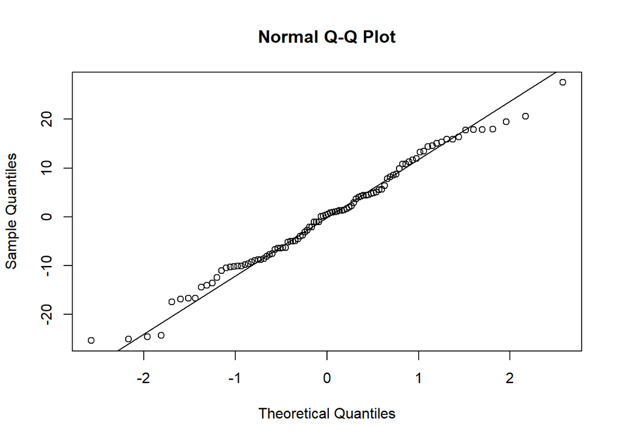

```r
qqnorm(modelo_final$residuals)
qqline(modelo_final$residuals)
```

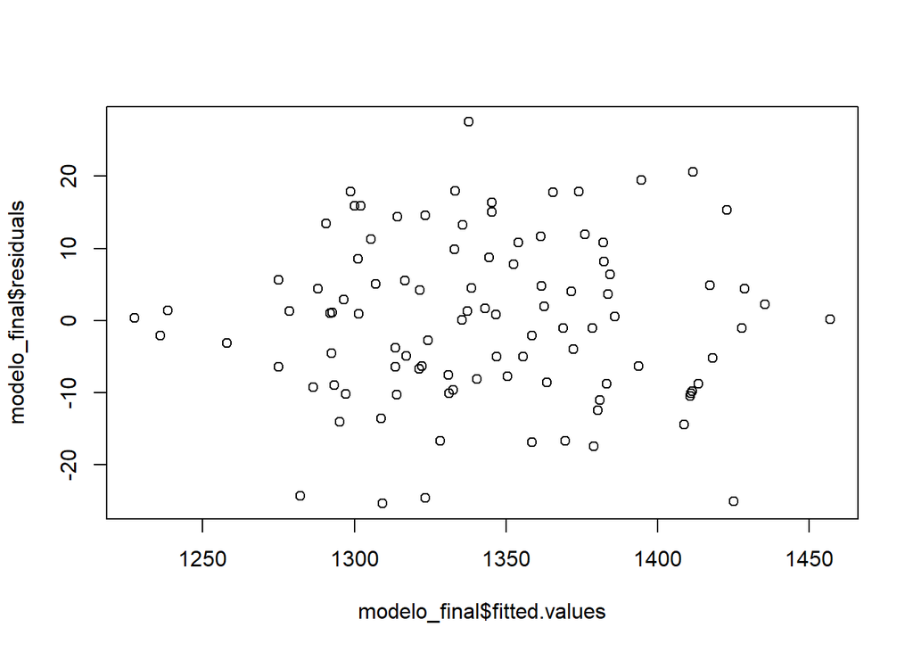

```r
# Hipótesis de Homocedasticidad
plot(modelo_final$fitted.values, modelo_final$residuals)
```

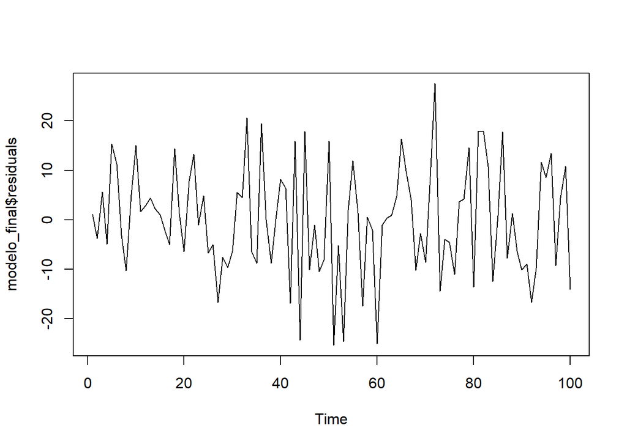

```r
# Hipótesis de Independencia
ts.plot(modelo_final$residuals)

library(lmtest)
```

```r
dwtest(modelo_final, alternative = "two.sided")
```

```
##
##  Durbin-Watson test
##
## data:  modelo_final
## DW = 2.1241, p-value = 0.5399
## alternative hypothesis: true autocorrelation is not 0
```

```r
# Comprobamos si existe multicolinealidad en los regresores.
library(rms)
vif(modelo_final)
```

```
##       X2       X4
## 1.000508 1.000508
```

```r
vif(modelo_completo)
```

```
##       X1       X2       X3       X4       X5
## 1.026992 3.766419 3.788904 1.028662 1.014034
```

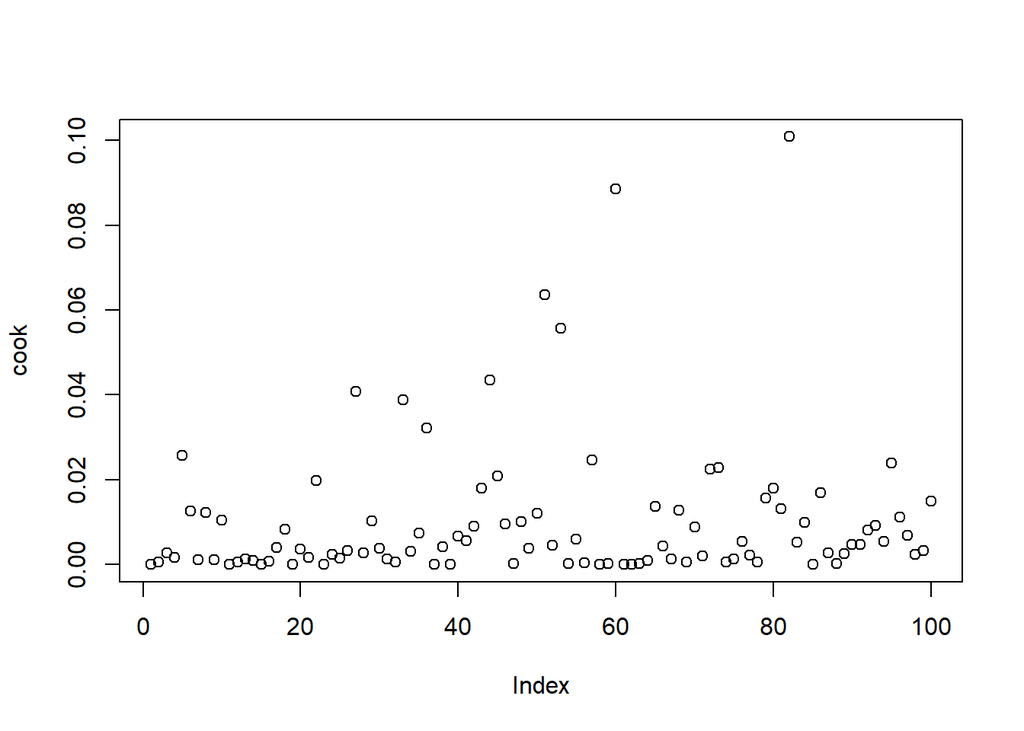

```r
# Lo último es comprobar que no hay observaciones influyentes, para ello calcularé
# la distancia de Cook para cada observación.

cook <- cooks.distance(modelo_final)
plot(cook)
```

```r
nuevos <- data.frame(X2 = 500, X4 = 950)
predict(modelo_final, newdata = nuevos, interval = 'prediction', level = 0.95)
```

```
##        fit      lwr      upr
## 1 1313.818 1291.261 1336.374
```

```r
predict(modelo_final, newdata = nuevos, interval = "confidence", level = 0.95)
```

```
##        fit     lwr      upr
## 1 1313.818 1310.88 1316.755
```

```r
nuevos <- data.frame(X2 = 500, X4 = 300)
predict(modelo_final, newdata = nuevos, interval = 'prediction', level = 0.95)
```

```
##       fit      lwr      upr
## 1 854.789 818.6868 890.8911
```

```r
predict(modelo_final, newdata = nuevos, interval = "confidence", level = 0.95)
```

```
##       fit      lwr      upr
## 1 854.789 826.4478 883.1301
```

Con los datos obtenidos podemos descartar que la cantidad de zumo obtenida sea superior a 1300 litros, de hecho es todo lo contrario, ya que se espera que la producción media esté por 854.789 litros de zumo

# Problema 2

```r
V <- matrix(NA, 3, 3)
V[1,] <- c(2,1,2)
V[2,] <- c(1,4,2)
V[3,] <- c(2,2,4)

mu <- c(10, 30, 20)
```

```r
library(mvtnorm)
dmvnorm(x=c(20, 20, 20), mean = mu, sigma = V)
```

```
## [1] 2.042557e-31
```

```r
dmvnorm(x=c(12, 32, 22), mean = mu, sigma = V)
```

```
## [1] 0.00570772
```

```r
set.seed(456)
d <- mvrnorm(n=1000, mu=mu, Sigma = V)
```

```r
data.frame(mu, V)
```

```
##   mu X1 X2 X3
## 1 10  2  1  2
## 2 30  1  4  2
## 3 20  2  2  4
```

```r
data.frame(colMeans(d), cov(d))
```

```
##   colMeans.d.       X1       X2       X3
## 1     9.95139 1.921322 0.884214 1.940016
## 2    29.83107 0.884214 3.922521 1.921470
## 3    19.96085 1.940016 1.921470 3.856989
```

Se pueden apreciar diferencias de decimales,lo que indica que las medias teóricas están redondeadas y las medias muestrales dan datos mucho más precisos.

```r
library(mvnormtest)
mshapiro.test(t(d))
```

```
##
##  Shapiro-Wilk normality test
##
## data:  Z
## W = 0.99649, p-value = 0.02457
```

```r
dM1 <- mahalanobis(d, center = mu, cov = V)

dM2 <- mahalanobis(d, center = colMeans(d), cov = cov(d))

max(dM1)
```

```
## [1] 16.84231
```

```r
max(dM2)
```

```
## [1] 18.79291
```